# Coursework Report

*N* removed NAs: 3

*N* removed typo: 1

*N* removed <18: 28

*N* total clean: 118

| Group | *N* | *M*<sub>age</sub> | *M*<sub>rating</sub> |
| --- | --- | --- | --- |
| Control | 54 | 21.0 | 5.43 |
| Experim | 64 | 20.9 | 6.05 |

**Main analysis results**

*t*(116) = -4.31, *p* < .001

[interactive chart not shown]

[figure not shown]

[interactive chart not shown]

# Coursework Report

Analysing Data, Spring 2020

# Methods

## Participants

Table 1 *Descriptive statistics by Condition*

| CONDITION | *N* | % | *M*<sub>age</sub> | *SD*<sub>age</sub> |
| --- | --- | --- | --- | --- |
| control | 54 | 45.8 | 21.0 | 2.19 |
| experimental | 64 | 54.2 | 20.9 | 1.99 |

## Design

This study aimed to understand what influences women’s physical attraction to men. They did this, by examining the effect of the colours red and white on a female’s perception of the male’s level of attraction.

The variables that will be used in the analysis for this study are the condition (independent variable) that the females were grouped into and items 1-3 (dependent variable), which is their rating scores of perceived attractiveness in response to the three questions asked. The three questions asked were, ‘How attractive do you think this person is?’, ‘How pleasant is this person to look at?’ and lastly ‘If you were to meet this person face to face, would you think he is attractive?’ The independent condition variable is a factor, which was created with two levels ‘control’ and ‘experimental.’ The ‘control’ level refers to the 54 females that were shown a photo of a male on a white background, and the ‘experimental’ level is the remaining 64 females shown a photo of a male on a red background. The dependent variable (Items 1-3) are ratings, measured using a 9-point Likert scale. If the participant scored a 1, this implies a low rating of perceived attractiveness and hence scoring a 9 implies a high rating of perceived attractiveness.

The operational hypothesis for this study is therefore, “A female’s perceived attractiveness rating score of a male, will be greater when the male is associated with the colour red, in comparison to the colour white.” The statistical analysis required to test this hypothesis is an independent-measures *t*-test to analyse the composite score of the rating variables for each colour condition.

# Results

Overall, the results display that the mean composite rating score for the experimental condition appeared 0.62 higher than the control condition. This implies that the female subjects in the red colour group (experimental) had greater perceived attraction of the male in the photograph, compared to the white colour group (control). The mean composite rating scores were calculated by finding the mean of all three rating scores for each participant.

Using this data, a means plot was calculated to show the variation in the means for the red colour group (experimental condition) and the white colour group (control condition). This means plot can be seen below.

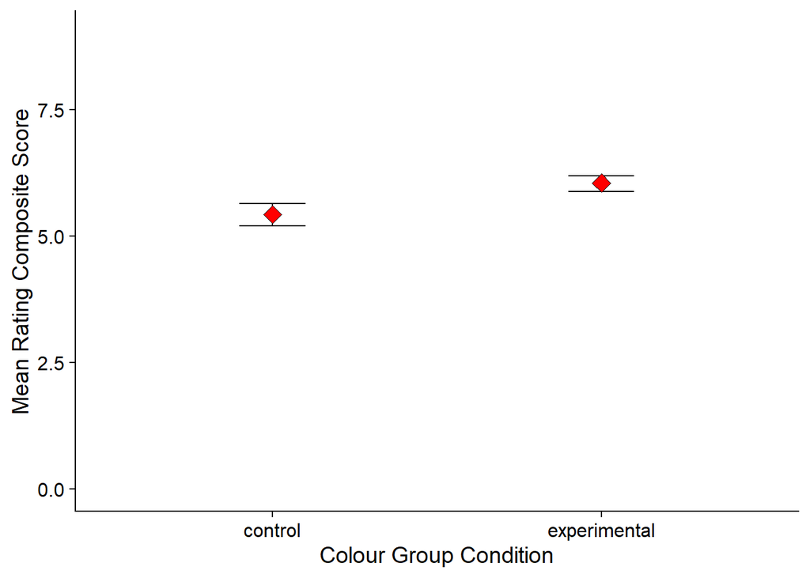

From this means plot and the results of the independent-measures *t*-test, it can be concluded that the mean for the control condition was 5.43, which was lower than the mean for the experimental condition 6.05. This test showed that the means for each condition did vary, (*M*<sub>diff</sub> = -0.62, 95% CI [-0.91, -0.34]) and hence there was a significant difference between the ratings of perceived attractiveness for the white colour group (control) and the red colour group (experimental) conditions (*t* (116) = -4.31, *p* < .001.

Finally, a summary of the data can be seen below, displaying the descriptives of the composite rating scores for each condition.

Table 1 *Descriptive statistics by Condition for Composite Score*

| CONDITION | *mean*<sub>comp</sub> | *SD*<sub>comp</sub> | *min*<sub>comp</sub> | *max*<sub>comp</sub> |
| --- | --- | --- | --- | --- |
| control | 5.43 | 0.87 | 3.00 | 7.00 |
| experimental | 6.05 | 0.70 | 4.33 | 7.33 |

# Discussion

In summary, the results of this study indicate that a male associated to the colour red is predominantly perceived as more attractive by females, than a male associated to the colour white. This is evident as, the mean rating score for the control condition was significantly lower than the mean rating for the experimental condition. In addition to this, the error bars for the control condition appear slightly further apart than for the experimental condition. This can presume that the composite rating scores for the experimental condition were more precise than scores in the control condition, further supporting the operational hypothesis that the colour red associated to a higher rating of perceived attractiveness than the colour white.

In comparison to the original study (Elliot et al, 2010), both sets of data concluded that there was a significant difference between perceived attractiveness, with red resulting in higher rating scores. The composite mean scores for the original study were very similar to my data set, 6.79 for the Experimental condition and 5.67 for the Control condition. Therefore, both sets of data imply that the Red effect for females aged 18-27 is apparent. However, this sample of participants is both age and gender specific and hence not generalisable to the wider population (W. Kukull and M. Ganguli, 2012). Other research in this field speculates contrary findings for the Red effect.

(S.Peperkoorn et al, 2016) investigated the red colour effect in males with three experimental variations. They included the colour black; changed the culture of the sample and increased the sample size. Interestingly, all three studies failed to support that red enhances perceived attractiveness. This research would hence reject my operational hypothesis. These findings are important as, by including more participants who were of a broader age range and opposite gender, makes this study more representative. This raises the concern that in a larger sample, the red effect is not notable and thus questions the reliability of my original data.

Nevertheless, in (Elliot et al, 2010) original study, no participants understood the true reason they were taking part in the study. This is advantageous as it implies the data was not influenced by social desirability bias, meaning the subjects did not alter their ratings to support what the study was investigating (Lavrakas, 2008). However, a form of bias may arise from the Investigator, with regards to how the three questions were asked. Altering the tone and emphasis of a question could persuade the participant to lean more towards a certain response (in this case, rating the colour red higher) (Wynder, 1994). In addition to this, it is not considered that the colour red may have other connotations, other than increasing perceived attraction. I am of the view, that the effect of red on perceived attraction is real, however, this data was accumulated from only American females. (Huang, 2011) investigated how the colour red is implemented in Chinese culture, and found it associates to joy, marriage and celebration. This suggests, the colour red can have very different meanings for cultures, and this could link to why red is a more favourable colour in comparison with white or black in previously mentioned studies. I believe this research area should be investigated further, to comprehend other connotations to the colour red, and thus if the association of red and perceived attraction is as established as my data shows.

A suggestion for a future study could involve altering (Elliot et al, 2010) design, by including a qualitative analysis of the participants perception of red with regards to their culture, after they see the photographs. This would require a sample of participants from a variety of different cultures, which in turn would increase the generalisability of the study. The participants would follow the same procedure as the original study, however, afterwards the researcher can ask “What do you associate the colours white and red with, in respect to the culture you were brought up in?” It is essential to ask about all colours in the study, to reduce the participants guessing the true aim of the experiment. By including this analysis in the study, it will show if the participants have pre-existing connotations to the colour red, and possibly provide a more detailed insight into why red resulted in a greater rating of perceived attraction.

To conclude, the perception of the colour red is a huge area of research, with many contrasting findings. Despite research from (S.Peperkoorn et al, 2016) providing data against the colour red increasing perceived attraction, my data and analysis clearly state the opposite. Both studies share minor design flaws, but the significant difference in composite means for each condition in my data, makes it impossible to ignore that the colour red does increase perceived attraction to a certain extent.

# References

Elliot et al. (2010). Red, Rank and Romance in Women Viewing Men. Journal of Experimental Psychology, 399-417.

Huang, Q. (2011). A study on the metaphor of “red” in chinese culture. American International Journal of Contemporary research, Vol.1 No.3.

Lavrakas, P. J. (2008). Social Desirability . Retrieved from methods.sagepub.com: https://methods.sagepub.com/reference/encyclopedia-of-survey-research-methods/n537.xml

S.Peperkoorn et al. (2016). Revisiting the red effect on attractiveness and sexual receptivity. SAGE journals.

W. Kukull and M. Ganguli. (2012). Generalizability . American Academy of Neurology, 1886-91.

Wynder, E. l. (1994). Investigator bias and interviwer bias: the problem of reporting sytematic error in epidoemiology . Journal of Clinical Epidemiology , 184-8.